# Análisis de Chistes

Análisis de chistes scrapeados. Proyecto de la asignatura Mineria de Texto, MADM, UIB.

Josep R.C. https://www.linkedin.com/in/josep%F0%9F%8C%AB-roman-cardell-414880184/ (UIB Student)https://www.uib.cat/  
2021-04-30

**Librerias**

```r
library(tidyverse)
library(tidytext)
library(jsonlite)
library(rjson)
library(magrittr)
library(ggplot2)
library(stringr)
library(topicmodels)
library(textclean)
library(rmarkdown)
```

# 1. Lectura Json

- `1000chistes.json` contiene una *array* de objetos, i.e. `[{},...,{}]`.
  - Las variables *title* y *text* tinene un valor por fila.
  - Las variables *categories* y *tags* pueden tener varios valores por lo que complica el hecho de tener un chiste por fila. Estas dos columnas no se tendrán en cuenta para el análisis.
- `chistes_Pintamania.json` contiene una *array* de objetos.
  - Un valor por fila y atributo.
  - Además de título, categoría y texto, tiene los votos de cada chiste.

**Carga 1000Chistes**

```r
options(width = 60)
data1 = jsonlite::fromJSON("Data/1000chistes.json") %>% select(c(title, text))
head(data1)
```

```
                     title
1  Dime con quién andas...
2           Luz automática
3       Política argentina
4               0 positivo
5            Mejor portero
6 Donación para la piscina
                                                                                                                                                                                                                                                                                    text
1                                                                                                                                                                                                    - Dime con quién andas y te diré quién eres. \n- No ando con nadie... \n- Eres feo.
2 Va el marido completamente borracho y le dice a su mujer al irse para cama: \n- Me ha pasado algo increíble. He ido al baño y al abrir la puerta se ha encendido la luz automáticamente, sin hacer nada. \n- ¡La madre que te parió!, ¡Te mato!, ya te has vuelto a mear en la nevera.
3                          Un diputado argentino se encuentra en la calle con un amigo de la infancia y éste le pregunta:\n- ¿Cómo estás llevando esta crisis?\n- ¡La verdad que duermo como un bebé!\n- ¡Dormís como un bebé! ¿Pero cómo hacés?\n- ¡Me despierto cada 3 horas llorando!
4                                                                                                                                                                            - ¡Rápido, necesitamos sangre!\n- Yo soy 0 positivo.\n- Pues muy mal, necesitamos una mentalidad optimista.
5                                                                                                                                                                                                                - ¿Cuál es el mejor portero del mundial? \n- Evidente ¡el de Para-guay!
6                                                                                                                                                   El otro día unas chicas llamarón a mi puerta y me pidieron una pequeña donación para una piscina local. \nLes di un garrafa de agua.
```

**Carga 1000Chistes**

```r
summary(data1, 5)
```

```
    title               text
 Length:2422        Length:2422
 Class :character   Class :character
 Mode  :character   Mode  :character
```

El primer dataset contiene 2422 chistes.

**Pintamania**

```r
data2 = jsonlite::fromJSON("Data/chistes_Pintamania.json") %>% select(-votes)
head(data2, 5)
```

```
                                   title         categories
1                       JAIMITO Y TABLAS Chistes infantiles
2                QUE PASA SI MEZCLAS ... Chistes infantiles
3                    EL TECHO Y EL TECHO Chistes infantiles
4           CUAL ES EL COLMO DE UN CALBO Chistes infantiles
5 QUE LEDICE UN CEMAFORO A OTRO SEMAFORO Chistes infantiles
                                                                                  text
1                        Jaimito cuanto es 2 por 2 empate\nY cuanto es 2 por 1 oferta.
2 QUE PASA SI MEZCLAS UNA MOTO CON UNA MAQUINA DE CHICLES, TE DA UNA MOTOCHICLETAA :).
3                                ¿Qué le dice un techo a otro teche? Te echo de menos.
4                                                       Que tenga ideas descabelladas.
5                                           Dice no me mires que me estoy cambiando\n.
```

**Pintamania**

```r
summary(data2)
```

```
    title            categories            text
 Length:4750        Length:4750        Length:4750
 Class :character   Class :character   Class :character
 Mode  :character   Mode  :character   Mode  :character
```

El archivo de *pintamania* contiene 4750 objetos. En este caso la variable categoría tiene un solo valor por fila, por lo que se ha podido definir un atributo para ese valor que puede ser de útilidad más adelante.

# 2. Corpus

En este caso los documentos que forman el corpus son dos, los chistes de la web *1000chistes* y los de *Pintamania*. El corpus contiene el texto a analizar, además de el título del texto, el documento al que pertenecen y en el caso de la segunda web también la categoría a la que pertenecen.

**Corpus**

```r
corpus <- bind_rows(data1 %>%
                       mutate(web = "1000chistes"),
                     data2 %>%
                       mutate(web = "Pintamania")
                     )
head(corpus, 5)
```

```
                    title
1 Dime con quién andas...
2          Luz automática
3      Política argentina
4              0 positivo
5           Mejor portero
                                                                                                                                                                                                                                                                                    text
1                                                                                                                                                                                                    - Dime con quién andas y te diré quién eres. \n- No ando con nadie... \n- Eres feo.
2 Va el marido completamente borracho y le dice a su mujer al irse para cama: \n- Me ha pasado algo increíble. He ido al baño y al abrir la puerta se ha encendido la luz automáticamente, sin hacer nada. \n- ¡La madre que te parió!, ¡Te mato!, ya te has vuelto a mear en la nevera.
3                          Un diputado argentino se encuentra en la calle con un amigo de la infancia y éste le pregunta:\n- ¿Cómo estás llevando esta crisis?\n- ¡La verdad que duermo como un bebé!\n- ¡Dormís como un bebé! ¿Pero cómo hacés?\n- ¡Me despierto cada 3 horas llorando!
4                                                                                                                                                                            - ¡Rápido, necesitamos sangre!\n- Yo soy 0 positivo.\n- Pues muy mal, necesitamos una mentalidad optimista.
5                                                                                                                                                                                                                - ¿Cuál es el mejor portero del mundial? \n- Evidente ¡el de Para-guay!
          web categories
1 1000chistes       <NA>
2 1000chistes       <NA>
3 1000chistes       <NA>
4 1000chistes       <NA>
5 1000chistes       <NA>
```

**Tokenization**

```r
tidy_chistes <- corpus %>%
  unnest_tokens(word, text)
head(tidy_chistes, 5) #antes de descartar stopwords
```

```
                    title         web categories  word
1 Dime con quién andas... 1000chistes       <NA>  dime
2 Dime con quién andas... 1000chistes       <NA>   con
3 Dime con quién andas... 1000chistes       <NA> quién
4 Dime con quién andas... 1000chistes       <NA> andas
5 Dime con quién andas... 1000chistes       <NA>     y
```

El texto ha sido *tokenizado*, por defecto los signos de puntuación se han eliminado y se han transformado las mayúsculas a minúsculas.

```r
max(nchar(tidy_chistes$word))
```

```
[1] 176
```

Ninguna palabra contiene tantos caracteres. Se debería investigar y filtrar los terminos que no son palabras. A continuación se eliminarán los números:

```r
words <- tidy_chistes$word %>% replace_number(remove=T)
tidy_chistes %<>% filter( word %in% words)
```

También se han eliminado las *stop words* usando la lista de palabras en español del paquete *tm*.

**Stop Words**

```r
tmstop_words = data_frame(word = tm::stopwords("spanish"), lexicon = "custom")

tidy_chistes2 <- tidy_chistes %>%
  anti_join(tmstop_words)
```

Tras eliminar las palabras menos relevantes el corpus se ha reducido un 49.1%. De estas las más frecuentes son las siguientes.

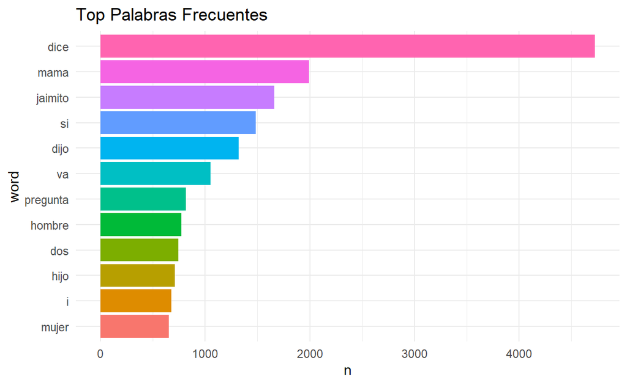

```r
tidy_chistes2 %>%
  count(word, sort = T) %>%
  filter(n > 650) %>%
  mutate(word = reorder(word, n)) %>%
  ggplot(aes(n, word, fill = factor(word))) +
    geom_col() +
    theme_minimal() +
    theme(legend.position = "none") +
    ggtitle("Top Palabras Frecuentes")
```

# 3. Frecuencias

A continuación se ha calculado la distribución de las frecuencias de las palabras por separado para cada página web.

**Frecuencia por web**

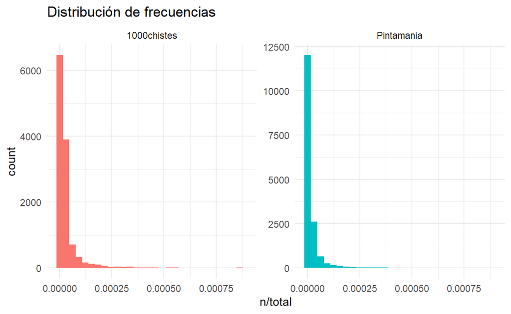

```r
chistes_words <- tidy_chistes %>%
  count(web, word, sort = T)

total_words <- chistes_words %>%
  group_by(web) %>%
  summarize(total = sum(n))

chistes_words %<>% left_join(y = total_words, by = "web")

ggplot(chistes_words, aes(n/total, fill = web)) +
  geom_histogram(show.legend = F) +
  xlim(NA, 0.0009) +
  facet_wrap(~web, scales = "free_y") +
  ggtitle("Distribución de frecuencias") +
  theme_minimal()
```

La distribución es similar, muchas palabras aparecen pocas veces y menos palabras con una frecuencia de aparición alta. Se puede observar que dado un mínimo de palabras la distribución sobre el eje horizontal es similar. El eje *y* por otro lado, tiene distinta escala para cada documento debido a que *Pintamania* tiene casi el doble de observaciones.

### Ley de Zipf

**Zipf’s Law**

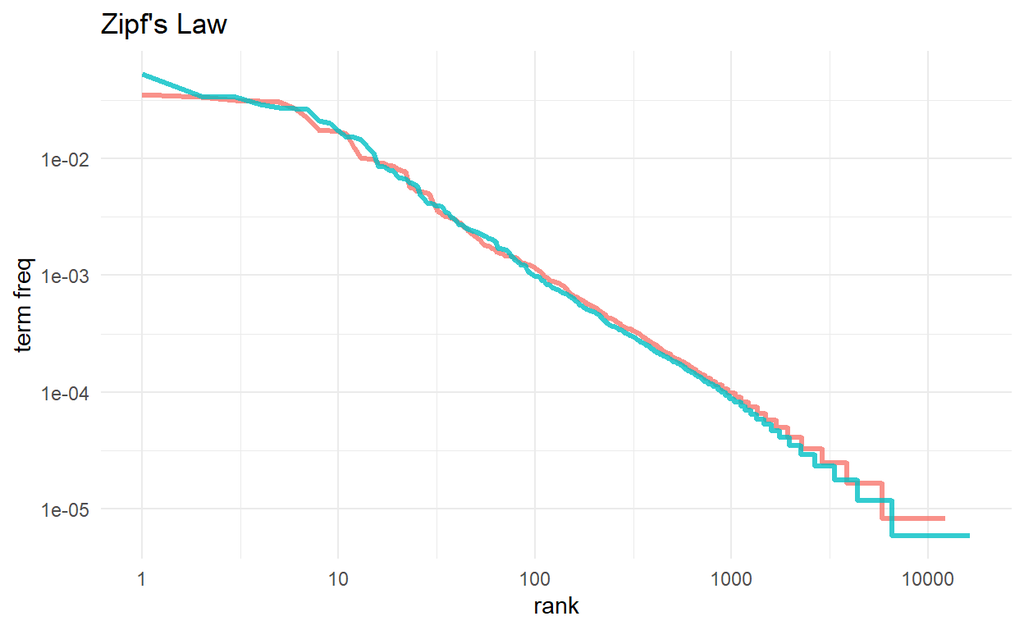

```r
freq_by_rank <- chistes_words %>%
  group_by(web) %>%
  mutate(rank = row_number(),
         `term freq` = n/total) %>%
  ungroup()

freq_by_rank %>%
  ggplot(aes(rank, `term freq`, color = web)) +
  geom_line(size = 1.1, alpha = 0.8, show.legend = FALSE) +
  scale_x_log10() +
  scale_y_log10() +
  ggtitle("Zipf's Law") +
  theme_minimal()
```

### tf-idf

En está sección se ha analizado la importancia de las palabras usando la métrica **tf-idf**. Con está se pretende identificar cuales son las palabras más importantes para cada web, esto es en el caso de estudio, que **palabras son muy frecuentes en una página y al mismo tiempo no aparecen en la otra**. A primera vista, al albergar ambos documentos chistes de múltiples categorías con un tono similar, las palabras más frecuentes se encontrarán en ambas webs, entonces la idea es ver si cada web se caracteriza por usar algunas palabras menos comunes.

Para este análisis no se han eliminado las *stop words* ya que están son descartadas en un inicio al ser su valor para la métrica *idf* igual a 0.

**tf-idf**

```r
chistes_tf_idf <- chistes_words %>%
  bind_tf_idf(word, web, n)

chistes_tf_idf %>%
  select(-total) %>%
  arrange(desc(tf_idf)) %>%
  head(10) %>%
  paged_table()
```

|  | web | word | n | tf | idf | tf_idf |
| --- | --- | --- | --- | --- | --- | --- |
| 1 | Pintamania | q | 515 | 0.0030087224 | 0.6931472 | 0.0020854874 |
| 2 | Pintamania | ke | 168 | 0.0009814861 | 0.6931472 | 0.0006803143 |
| 3 | Pintamania | ala | 124 | 0.0007244302 | 0.6931472 | 0.0005021368 |
| 4 | Pintamania | xd | 97 | 0.0005666914 | 0.6931472 | 0.0003928005 |
| 5 | Pintamania | avia | 68 | 0.0003972682 | 0.6931472 | 0.0002753653 |
| 6 | Pintamania | abia | 66 | 0.0003855838 | 0.6931472 | 0.0002672664 |
| 7 | Pintamania | entonses | 64 | 0.0003738995 | 0.6931472 | 0.0002591674 |
| 8 | Pintamania | r | 62 | 0.0003622151 | 0.6931472 | 0.0002510684 |
| 9 | Pintamania | avion | 56 | 0.0003271620 | 0.6931472 | 0.0002267714 |
| 10 | Pintamania | havia | 54 | 0.0003154777 | 0.6931472 | 0.0002186725 |

La primera observación sobre la tabla anterior es que el valor *idf* es el mismo para todas las palabras ya que solo hay dos paginas web, entonces solo puedes ser 0.69 o 0. También comentar que la diferencia de chistes entre ambas webs es significativa por lo que con menos apariciones de una palabra, *n*, es suficiente en la web de *1000Chistes* para obtener un valor más elevado de *tf-idf*. Por esto, se han separado los valores de está métrica por página web para visualizar de forma clara que palabras son más importantes para cada página.

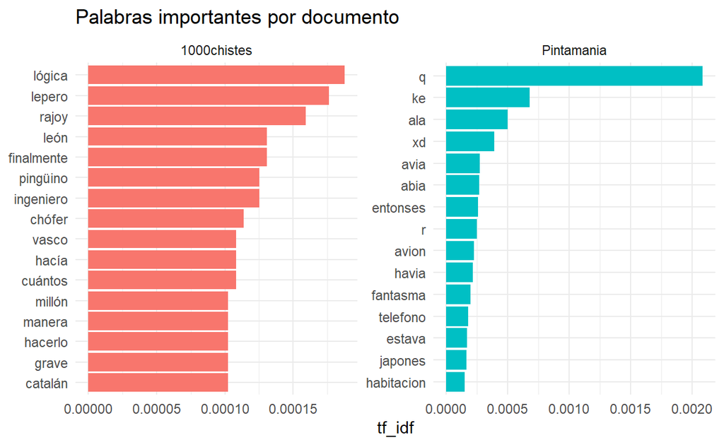

```r
chistes_tf_idf %>%
  group_by(web) %>%
  slice_max(tf_idf, n= 15) %>%
  ungroup() %>%
  ggplot(aes(tf_idf, fct_reorder(word, tf_idf), fill = web )) +
  geom_col(show.legend = F) +
  facet_wrap(~web, scales = "free") +
  labs(y = NULL) +
  ggtitle("Palabras importantes por documento") +
  theme_minimal()
```

En el gráfico de la izquierda se pueden detectar algunos tópicos de los chistes españoles como los chistes de leperos o los chistes de vascos y catalanes. Además, algunas palabras reflejan categorías voluminosas que no están en *Pintamania* como por ejemplo, chistes de *rajoy*, *ingenieros* y *chóferes*. Por otra parte el gráfico de la derecha refleja la ya comentada baja calidad de esta página, donde se observa que las palabras más importantes son faltas ortográficas. Destacar que en el top 10 de palabras importantes se encuentran tres formas de escribir de forma errónea la palabra *había* y las dos primeras también son formas erróneas de la conjunción, *que*. En general todas las palabras del top de *Pintamania* son palabras que no aparecen en *1000Chistes* debido a que están mal escritas, por lo que no podemos detectar ninguna temática especial en esta página. En conclusión, se han podido identificar temáticas importantes en el documento de *1000Chistes*, aunque debido a la tendencia de *Pintamania* en contener tantas faltas ortográficas y que muchas de las palabras del ranking de la izquierda contienen acentos es posible que palabra como león o catalán si formen parte del corpus de *Pintamania* pero que contengan faltas ortográficas.

```r
corpus %>%
  filter(str_detect(text, "catalan ")) %>%
  select(text, web)
```

```
                                                                                                                                                                                                                                                                                                            …
1                                                                                                                                                                                                                                                Tu sabes un catalan cuando tiene frio?se arrima a la estufa…
2 Habian un chino,un catalan y un frances;y van a un hotel.Y el chino va a su habitacion y oye:"SACATE LA ROPA QUE TE VOY A COMER"y se tira por la ventana.Despues al frances y el catalan les pasa lo mismo.El mayordomo se va a ver porque todo el mundo que va se tira y encende la luz y ve a un mono co…
         web
1 Pintamania
2 Pintamania
```

Se confirma la hipótesis anterior, aunque solo aparecen dos chistes por lo que sigue siendo más característico para el otro documento.

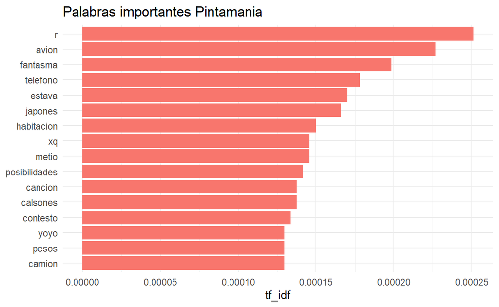

```r
stopwords2 <- data.frame(word = c("q", "ke", "ala", "xd", "avia", "abia", "havia", "entonses"))

chistes_tf_idf %>%
  anti_join(stopwords2) %>%
  filter(web == "Pintamania") %>%
  slice_max(tf_idf, n= 15) %>%
  ggplot(aes(tf_idf, fct_reorder(word, tf_idf), fill = web )) +
  geom_col(show.legend = F) +
  labs(y = NULL) +
  ggtitle("Palabras importantes Pintamania") +
  theme_minimal()
```

Siguiendo con el mismo tónica, son palabras con faltas ortográficas y es probablemente por esto que no aparecen en el otro documento del corpus.

```r
corpus %>%
  filter(str_detect(text, " r ")) %>%
  select(text, web)
```

```
                                                                                                                                                                                                                                                                                                            …
1                                                                                                                                                                                      Una señora lleva su hijo al logopeda(no puede pronunciar la r) y la mama del niño le dice al logopeda:traigo a mi niñ…
2                                                                                                                                                                                                      Aixo eraa un xino que no sebia dir se r i tenia un veinat que li deien curo i tenia cans i els molest…
3 Estan en clase de lengua jaimito,pepito y juanito y la profesora ruperta le dice : Pepito Pepito como se dice la r con la e y dice: re y si le añades una tilde y dice ré,la profesora le dice a Juanito : Juanito Juanito como se dice la s con la i y dice: si y si le añades una tilde y dice: sí y por…
4                                                                                                                                                                                                          En la plaza, 9 de la maañana una manifestacion de rubias y todaas gritan ¡¡¡las rubias no somos t…
5                                                                                                                                                                                                                                                                                                           …
6                                                                                                                                                                                                                                                                                                           …
         web
1 Pintamania
2 Pintamania
3 Pintamania
4 Pintamania
5 Pintamania
6 Pintamania
```

El caracter *“r”* aparece en 6 chistes pero claramente no tiene ningún significado.

# 4. DTM

En este apartado se ha procedido a modificar el formato de los datos. Hasta el momento se ha trabajado en el formato *tidy* y ahora se procederá a transformar al formato a DTM, el cual permite trabajar con varias librerías de *R* para el análisis de texto.

Este formato tiene una estructura distinta donde cada **columna representa una palabra** (*term*), cada **fila un documento**, y cada **valor es la frecuencia con la que un termino aparece en un documento**. Este hecho provoca que en un corpus con muchos documentos haya muchos valores nulos ya que no todas las palabras se encuentran en todos los documentos. Es por ello que esta estructura está contenida en una matriz *sparseada*.

En este caso se ha usado el dataframe que no contiene las stopwords, para que estás no aparezcan en la DTM. También se han eleminado las stopwords editadas apartir del ranking de palabras importantes de *Pintamania*.

**DTM**

```r
DTM <- tidy_chistes2 %>%
  count(web, word, sort=T) %>%
  anti_join(stopwords2, by = "word") %>%
  cast_dtm(web, word, n)

DTM
```

```
<<DocumentTermMatrix (documents: 2, terms: 23538)>>
Non-/sparse entries: 28283/18793
Sparsity           : 40%
Maximal term length: 176
Weighting          : term frequency (tf)
```

La matriz se ha creado correctamente, contiene 2 documentos y 23538 terminos distintos. Se puede observar que el porcentaje de *sparsity* no es muy elevado, hecho que se debe a que solo son dos documentos y que tratan sobre la misma temática por lo que comparten muchas palabras.

El parámetro *Maximal term length* indica que el termino más largo sigue siendo el de 176 caracteres. Con una análisis más exhaustivo se deberían eliminar los valores que no sean palabra.

# 5. Topic Modeling

En este apartado se ha aplicado un algoritmo no supervisado, similar a un clustering, para tratar de identificar temáticas en los documentos. Se ha aplicado un algoritmo conocido como *Latent Dirichlet Allocation*, **LDA**. Este es un método matemático basado en dos principios:

- Cada documento está formado por una mezcla de temáticas.
- Cada temática está formada por una mezcla de palabras.

El *input* para este algoritmo es la DTM definida en el apartado anterior y el parámetro *k* se ha definido de manera que divida entre 10 temáticas:

**LDA**

```r
lda_10 <- LDA(DTM, k = 10, control = list(seed = 1234))
lda_10
```

```
A LDA_VEM topic model with 10 topics.
```

### Probabilidad Palabra-Temática

Primero se ha analizado con que probabilidad las palabra pertenecen a una temática determinada.

**10 topics**

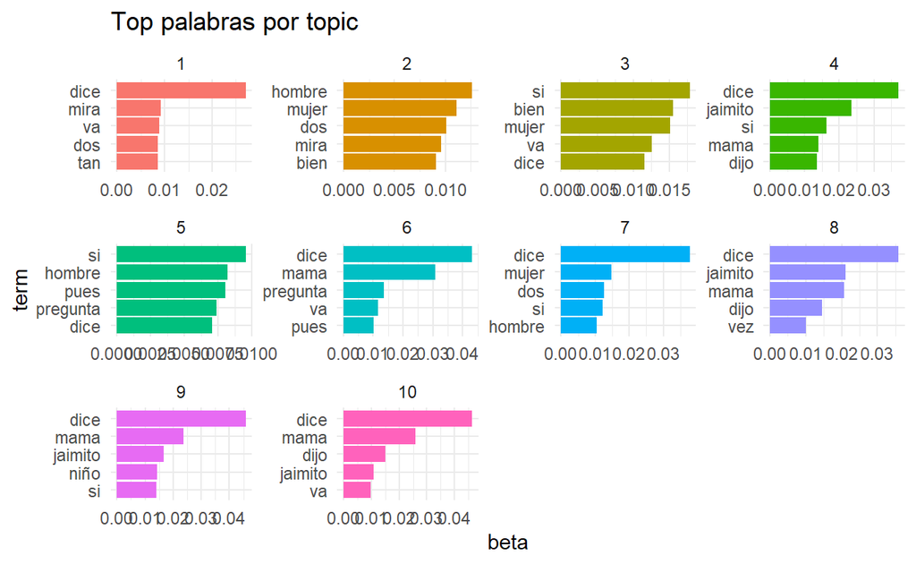

```r
topics_10 <- tidy(lda_10, matrix = 'beta')

top_terms_10 <- topics_10 %>%
  group_by(topic) %>%
  slice_max(beta, n = 5) %>%
  ungroup() %>%
  arrange(topic, -beta)

top_terms_10 %>%
  mutate(term = reorder_within(term, beta, topic)) %>%
  ggplot(aes(beta, term, fill = factor(topic))) +
  geom_col(show.legend = FALSE) +
  facet_wrap(~ topic, scales = "free") +
  scale_y_reordered() +
  ggtitle("Top palabras por topic") +
  theme_minimal()
```

La representación anterior muestra que la mayoría de palabras coinciden en las 10 temáticas que ha definido el modelo. Estas palabras coinciden con las más frecuentes del corpus en general. Con el fin de ajustar mejor las temáticas se ha realizado un análisi con un número más reducido de temáticas:

**5 topics**

```r
lda_5 <- LDA(DTM, k = 5, control = list(seed = 1234))
```

**beta**

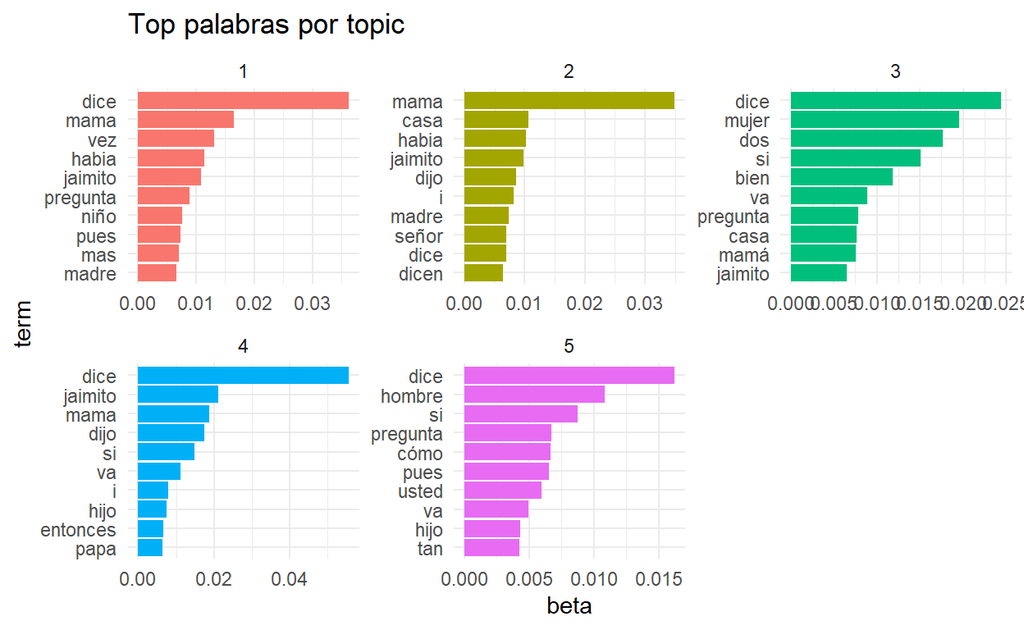

```r
topics_5 <- tidy(lda_5, matrix = 'beta')

top_terms_5 <- topics_5 %>%
  group_by(topic) %>%
  slice_max(beta, n = 10) %>%
  ungroup() %>%
  arrange(topic, -beta)

top_terms_5 %>%
  mutate(term = reorder_within(term, beta, topic)) %>%
  ggplot(aes(beta, term, fill = factor(topic))) +
  geom_col(show.legend = FALSE) +
  facet_wrap(~ topic, scales = "free") +
  scale_y_reordered() +
  ggtitle("Top palabras por topic") +
  theme_minimal()
```

Se puede observar como las palabras siguen siendo en general comunes a la mayoría de chistes sin definir claramente ninguna categoría. Para tratar de entender mejor que temáticas pueden haberse definido se ha considerado la detección de las palabras que más se diferencian en la probabilidad de aparición entre dos temática.

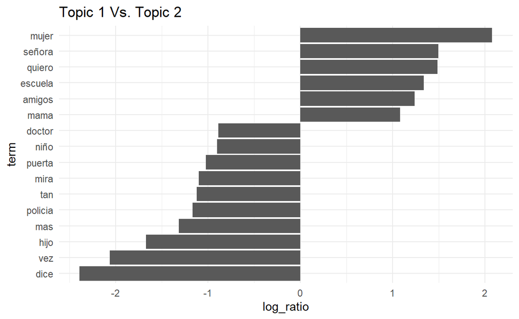

```r
beta_wide <- topics_5 %>%
  filter(beta > 0.001) %>%
  mutate(topic = paste0("topic", topic)) %>%
  pivot_wider(names_from = topic, values_from = beta) %>%
  mutate(log_ratio = log2(topic2/topic1))

beta_wide %>%
  top_n(abs(log_ratio), n = 16) %>%
  mutate(term = reorder(term, log_ratio)) %>%
  ggplot(aes(term, log_ratio)) +
    geom_col(show.legend = FALSE) +
    coord_flip() +
    ggtitle("Topic 1 Vs. Topic 2") +
    theme_minimal()
```

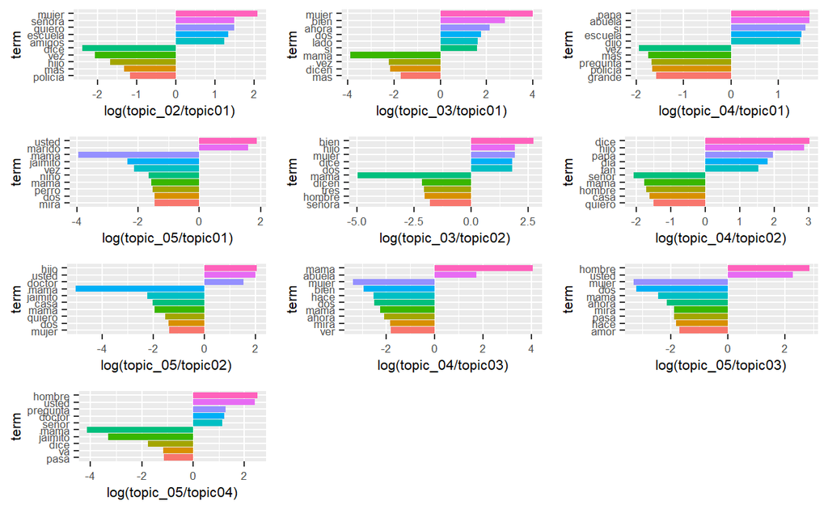

```r
num_topics = 5
pairwise_beta_plots = list()

for (i in 1:num_topics) {
  topic_i = as.name(paste0("topic",i))
  for (j in 1:num_topics) {
    topic_j = as.name(paste0("topic",j))

    if (i < j) {
      pairwise_beta_plots[[length(pairwise_beta_plots)+1]] =
        beta_wide %>%
          mutate(term = as.factor(term)) %>%
          select(term, UQ(topic_i), UQ(topic_j)) %>%
          filter(UQ(topic_i) > 0.001 & UQ(topic_j) > 0.001) %>%
          mutate(log_ratio = log2(UQ(topic_j) / UQ(topic_i))) %>%
          top_n(10, abs(log_ratio)) %>%
          arrange(sign(log_ratio), abs(log_ratio)) %>%
          mutate(term = reorder(term, row_number())) %>%
          ggplot(aes(term, log_ratio, fill=term)) +
            geom_col(show.legend = FALSE) +
            coord_flip() +
            ylab(sprintf("log(topic_%02d/topic%02d)", j, i)) +
            theme(text = element_text(size=8))
    }
  }
}

num_plots = length(pairwise_beta_plots)

do.call(
  gridExtra::grid.arrange,
  c(pairwise_beta_plots[1:num_plots],
    ncol=round(sqrt(num_plots))))
```

Comparando las temáticas dos a dos se encuentran palabras con frecuencias significativamente diferentes entre ellas. Aún así, en terminos generales no se puede identificar ninguna de las temáticas con una categoría existente de chistes.

### Probabilidad Termática-Documento

En este subapartado se han examinado las probabilidades de cada documento de pertenecer a una de las 5 temáticas anteriores.

**Gamma**

```r
docs <- tidy(lda_5, matrix="gamma")
docs %>%
  paged_table()
```

| document | topic | gamma |
| --- | --- | --- |
| Pintamania | 1 | 1.961473e-01 |
| 1000chistes | 1 | 1.304982e-06 |
| Pintamania | 2 | 2.225313e-01 |
| 1000chistes | 2 | 1.303826e-06 |
| Pintamania | 3 | 4.930036e-05 |
| 1000chistes | 3 | 2.991100e-01 |
| Pintamania | 4 | 5.812712e-01 |
| 1000chistes | 4 | 1.303826e-06 |
| Pintamania | 5 | 8.905870e-07 |
| 1000chistes | 5 | 7.008861e-01 |

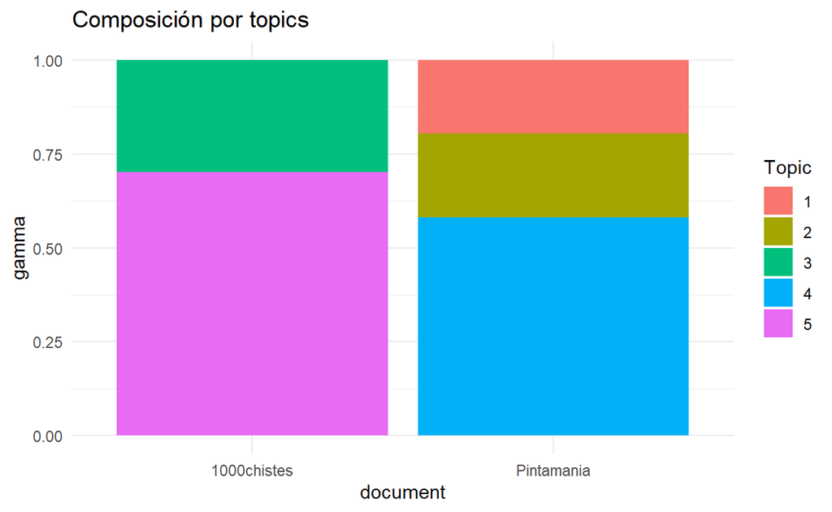

```r
docs %>%
  ggplot(aes(x  = document, y = gamma, fill = factor(topic))) +
  geom_bar(stat = "identity", position="stack") +
  ggtitle("Composición por topics") +
  scale_fill_discrete(name= "Topic") +
  theme_minimal()
```

### Relación categorias-topics

Cierto es que a simple vista no se observa una relación entre las temáticas definidas por el modelo y las categorías. A continuación se va a comprobar si realmente hay relación o no. Para ello se van a usar los chistes de *Pintamania* ya que cada observación está clasificada en su categoría. Se han seleccionado solo las categorías con un mínimo de 20 chites, son las siguientes:

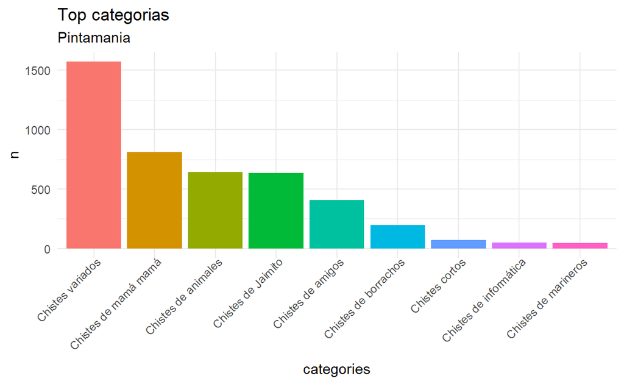

```r
cat <- data2 %>%
  group_by(categories) %>%
  summarise(n = n()) %>%
  filter(n > 20) %>%
  mutate(categories = reorder(categories, - n))

cat %>%
  ggplot(aes(categories, n, fill = factor(categories))) +
  geom_bar(stat="identity") +
  ggtitle("Top categorias", subtitle="Pintamania") +
  theme_minimal() +
  theme(legend.position = "none",
        axis.text.x = element_text(angle = 45, vjust = 1.1, hjust=1))
```

Se puede ver que la categoría con más chistes no pertenece a ninguna temática en si. Sin embargo, se ha mantenido la categoría para ver si alguna temática definida por el modelo puede captar la entropía de esta *categoría*.

Para poder calcular el grado de similitud entre los *topics* del modelo y las categorías de *Pintamania* se ha hecho un nuevo corpus en el cual los **documentos** ahora son las diferentes **categorias**. Para ello se ha vuelto a realizar el proceso de los apartados anteriores de *tokenización* y eliminación de las *stop words*, tanto las del paquete *tm* como las que se han añadido en apartados anteriores. Luego, a partir del corpus se ha calculado las metricas de *tf_idf* y se ha definido la DTM.

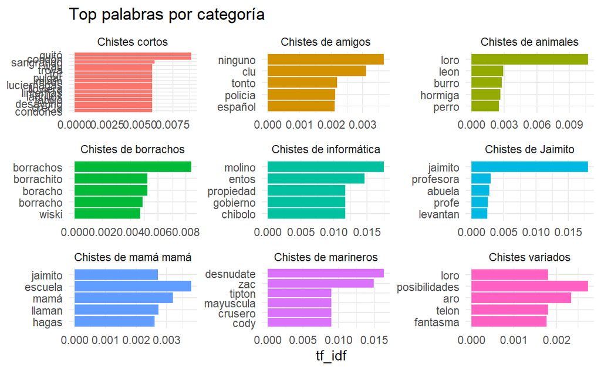

```r
corpus2 = data2 %>%
  select(categories, text) %>%
  filter(categories %in% cat$categories) %>%
  unnest_tokens(word, text) %>%
  anti_join(tmstop_words) %>%
  anti_join(stopwords2)

tf_idf_2 = corpus2 %>%
  count(categories, word, sort = T) %>%
  bind_tf_idf(word, categories, n)

tf_idf_2 %>%
  group_by(categories) %>%
  slice_max(tf_idf, n = 5) %>%
  ungroup() %>%
  ggplot(aes(tf_idf, fct_reorder(word, tf_idf), fill = categories )) +
  geom_col(show.legend = F) +
  facet_wrap(~categories, scales = "free") +
  labs(y = NULL) +
  ggtitle("Top palabras por categoría") +
  theme_minimal()
```

En algunas de las categorías las palabras más importantes no tienen mucho sentido, como por ejemplo en los chistes de amigos, pero para otras si que son palabras relevantes, como es el caso de los chistes de borrachos y los de Jaimito.

Para poder calcular la relación entre las temáticas y las categorías se volverán a calcular las betas filtrando los chistes de las categorías seleccionadas de *Pintamania*.

```r
DTM2 <- corpus2 %>%
  count(categories, word, sort = T) %>%
  cast_dtm(categories, word, n)
DTM2
```

```
<<DocumentTermMatrix (documents: 9, terms: 15457)>>
Non-/sparse entries: 25464/113649
Sparsity           : 82%
Maximal term length: 176
Weighting          : term frequency (tf)
```

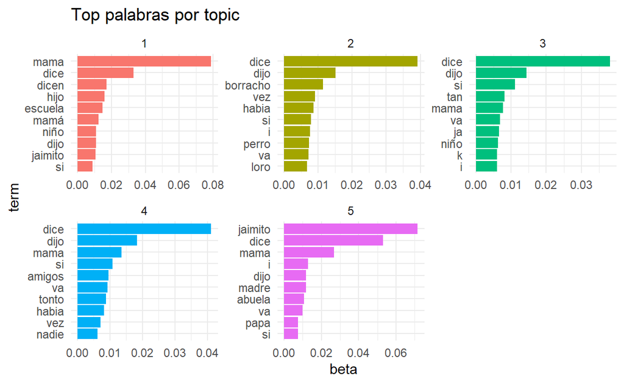

```r
lda2_5 <- LDA(DTM2, k = 5, control = list(seed = 1234))
topics2_5 <- tidy(lda2_5, matrix = 'beta')
top_terms2_5 <- topics2_5 %>%
  group_by(topic) %>%
  slice_max(beta, n = 10) %>%
  ungroup() %>%
  arrange(topic, -beta)

top_terms2_5 %>%
  mutate(term = reorder_within(term, beta, topic)) %>%
  ggplot(aes(beta, term, fill = factor(topic))) +
  geom_col(show.legend = FALSE) +
  facet_wrap(~ topic, scales = "free") +
  scale_y_reordered() +
  ggtitle("Top palabras por topic") +
  theme_minimal()
```

Finalmente, se han pivotado las dos tablas para poder calcular las correlaciones:

```r
tf_idf_wide2 <- tf_idf_2 %>%
  select(categories, word, tf_idf) %>%
  pivot_wider(names_from = categories, values_from = tf_idf, values_fill = 0)

beta_wide2 <- topics2_5 %>%
  # filter(beta > 0.001) %>%
  mutate(topic = paste0("topic", topic)) %>%
  pivot_wider(names_from = topic, values_from = beta, values_fill = 0)

tf_idf_wide2 %<>% column_to_rownames(var = "word")
beta_wide2 %<>% column_to_rownames(var = "term")
nrow(tf_idf_wide2) == nrow(beta_wide2)
```

```
[1] TRUE
```

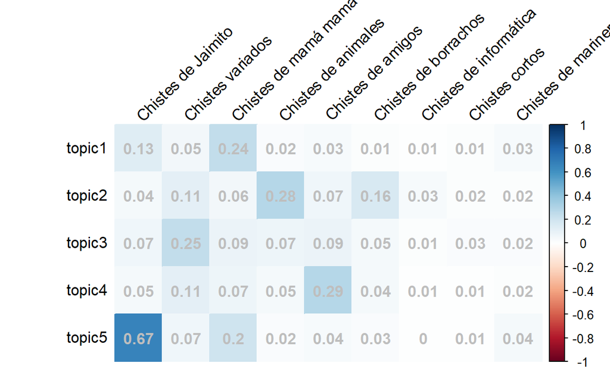

```r
cm = cor(tf_idf_wide2, beta_wide2, method = "pearson")
corrplot::corrplot(t(cm), method = "color",
                   addCoef.col = "grey",
                   tl.col = "black", tl.srt = 45)
```

Del correlograma anterior se puede afirmar que el *topic5* del modelo es el que está más definido por una categoría de chistes, los de *Jaimito*. Además que las categorías de *Jaimito* y *Mamá Mamá* están relacionadas, ya que los *topics* correlacionados con una temática están correlacionados con la otra, *topic1* y *topic5*. Los otros tres *topics* tinene una correlación débil con con algunas categorías de chistes.

El coeficiente $\beta$ mide la probabilidad de que una palabras se encuentre en un *topic*, entonces puede ser más adecuado mirar la correlación de está con la frecuencia de aparición de las palabras por categorías:

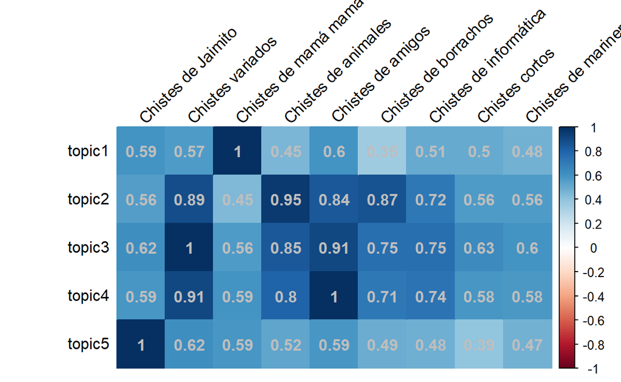

```r
tf_wide2 <- tf_idf_2 %>%
  select(categories, word, tf) %>%
  pivot_wider(names_from = categories, values_from = tf, values_fill = 0)
tf_wide2 %<>% column_to_rownames(var = "word")

cm2 = cor(tf_wide2, beta_wide2, method = "pearson")
corrplot::corrplot(t(cm2), method = "color",
                   addCoef.col = "grey",
                   tl.col = "black", tl.srt = 45)
```

Este último correlograma muestra unos valores más elevados que permiten entrever algunas relaicones entre categorías y *topics* que no difieren del correlograma anterior.

Como conclusión de este análisis, el modelo no ha podido diferenciar eficientemente entre las categorías de chistes. No obstante, no es de extrañar debido a la elevada proporción de faltas ortográficas que provoca la división de una misma palabra en 2, 3 y hasta 4 formas distintas. Además muchas palabras son comunes a la mayoría de categorías y no hay palabras significativamente características en todas ellas, como es el caso de *Jaimito*.